# R Community Explorer

Ben Ubah, Claudia Vitolo and Rick Pack

July 22, 2019

## Introduction

One of the most important assets of the R Language is its thriving community. There seems to be a friendly, welcoming and “togetherness” sense within the R community that has enhanced its expansion, adoption and have sustained user-groups in recent times.

In this year’s [Google Summer of Code program](https://summerofcode.withgoogle.com/organizations/4934391420157952/?sp-page=3#!), the proposal, [“Data-Driven Exploration of the R Community”](https://summerofcode.withgoogle.com/projects/#4662553878200320) was selected. Thanks to help from the project’s mentors, [Claudia Vitolo](https://www.linkedin.com/in/claudiavitolo/) and [Rick Pack](https://www.linkedin.com/in/rick-pack-mappstat-5320387).

The primary motivation for this project was the need to have a consistent, data-driven, automated dashboard that provides a broad overview of R User Groups and R-Ladies Groups globally.

The R Consortium and other stakeholders have invested in community expansion and sustenance initiatives like R-Ladies, R User Group Support (RUGS) program, Event Sponsorship, RCDI-WG and SatRdays, which in one way or another promotes the learning, use, and adoption of R in many under-represented regions. They have also significantly enhanced community engagement.

The R community has since progressed, but has there been a consistent/unified way to track this progress? Is there a way to find out which regions require more representation? How do we recognize the efforts of organizers who put in a lot of effort to organize events that keep user groups together, etc? How do we easily locate and recognize the most active groups and perhaps learn from their success? Could we somehow ascertain the impact of the initiatives set by the R Consortium and others on a global scale. Could there be a unified platform dedicated to exploring the R community? These were the thoughts that inspired this project.

This project is yet in its infancy, but we have started seeing some encouraging results after the first coding phase of Google Summer of Code. It is our hope to share what we have achieved so far with you and receive feedback where necessary.

## R-Ladies Groups

Since the [R Consortium](https://r-consortium.org) first funded the [R-Ladies](https://rladies.org) initiative, there has been a sporadic diffusion of their chapters and members globally. As a result of having a consistent and coherent leadership, and funding, R-Ladies groups are mostly managed on meetup.com, with a consistent naming convention. This makes it quite easy to find them on meetup.com and explore their data from the meetup API.

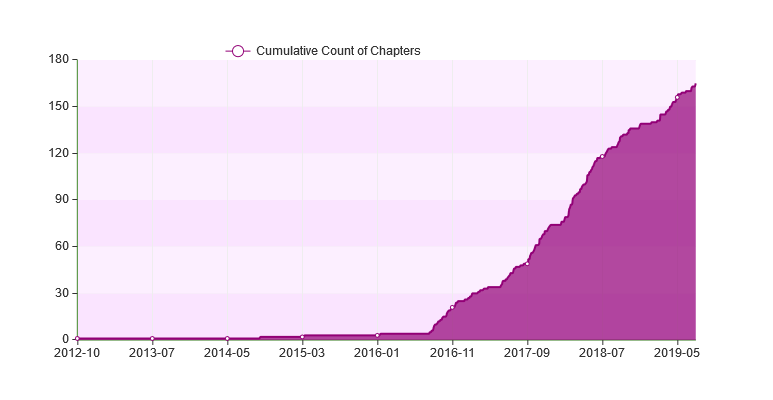

```
Chart showing Growth of R-Ladies Groups over the years
```

In the **first phase of Google Summer of Code**, this project explored a way to track R-Ladies Groups globally from the meetup API, using the `meetupr` package developed by R-Ladies.

This exploration was intended to be completely data-driven, automated but rendered via a static dashboard that would be hosted via GitHub Pages. R-Ladies already have a [shiny dashboard](https://gqueiroz.shinyapps.io/rshinylady/), that only runs on a Shiny Server. This dashboard formed part of the inspiration, but we went ahead to build this because we felt that there was more to be explored.

## What Has Been Achieved

For the R-Ladies dashboard, the following were achieved:

1. We used the `meetupr` package to extract R-Ladies Chapters from Meetup.com
2. Improved the existing `find_groups()` and `get_events()` functions in `meetupr` to meet our requirements
3. Transformed the data from Meetup to required formats
4. Persisted the data on GitHub
5. Developed a static HTML dashboard interface based on open-source Bootstrap template.
6. Rendered the persisted data via the dashboard interface.
7. Automated the process
8. Deployed it via GitHub Pages

## The Tools We Used

To accomplish the following, we used a mix of the tools listed below:

1. R, RStudio and the following packages:
   - meetupr, curl, jsonlite and leafletR
2. Javascript and the following libraries jquery.js, d3.js, echarts.js, leaflet.js and lodash.js
3. Gentelella Admin Dashboard Bootstrap HTML template
4. Travis CI to build the project, execute R scripts and bash commands
5. Bash commands to call R scripts and commit modified files to GitHub

## How We Achieved It

1. We used the meetupr package to retrieve R-Ladies Groups from meetup.com with an R script.
2. We further analyzed this data and computed several summaries out of it. We used the `leafletR` package to transform our data frame to GeoJSON. We used this GeoJSON file to create a leaflet map using on `leaflet.js`. In this map, R-Ladies groups are separated into three groups with markers of three color categories: **Active** (purple), **Inactive** (dark-purple), and **Unbegun** (orange). *Active* groups have had an event in the past 180 days or have an upcoming event in the future. *Inactive* groups have not had an event in the past 180 days and do not have an upcoming event. *Unbegun* groups have not had an event in the past and none planned for the future.
3. Persisted all data and our summaries in CSV / JSON files. After each Travis build, the data and our summaries gets updated straight from the Meetup API.
4. We wrote bash commands to run our R scripts, and commit updated CSV / JSON files to GitHub after every Travis build.
5. We setup Travis Cron Jobs, to build this project daily and update our data.
6. We then, customized the Gentelella Admin Dashboard Bootstrap HTML template to our requirements.
7. Rendered our summaries via widgets on this dashboard. Used Javascript/libraries to perform other simpler summaries and produce maps, charts and tables.

## The Result

At the end we have an [open-source dynamic dashboard for R-Ladies](https://benubah.github.io/r-community-explorer/rladies.html) that is daily updated, but is built to be static and is hosted via GitHub Pages. This could be seen as another approach to building information dashboards with R as a back-end technology, maintaining separation of business data-processing from data-presentation.

At the time of writing, there are **165** R-Ladies chapters, **50,000 +** members, across **47** countries, **162** cities, with almost **1590** past events and more upcoming. Our observation is that members are added to this community daily.

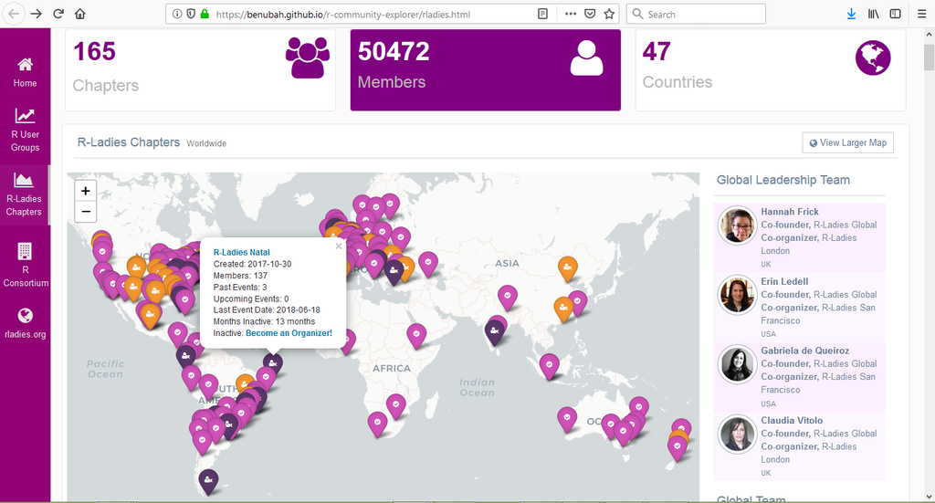

.

The pop-up markers in the leaflet map display important information about each R-Ladies chapter including a link to the group’s webpage, number of events, status, inactive months, and how to become an organizer for inactive/unbegun groups.

## Feedback

We are just starting this project and are in hopes of expanding its reach far beyond its current state and we would love to hear from you if you have any ideas of find issues. Feel free to Follow / Star the project at its GitHub repo: https://github.com/benubah/r-community-explorer/

## Next

We have started working on R user-groups generally and plan to report our progress soon and some lessons we have learnt.